# Using the RDML package

Konstantin A. Blagodatskikh, Michał Burdukiewicz, Stefan Rödiger, Andrej-Nikolai Spiess

2017-09-25

## 0.1 Introduction to the RDML package

The RDML package was created to work with the Real-time PCR Data Markup Language (RDML) – a structured and universal data standard for exchanging quantitative PCR (qPCR) data (Lefever et al. 2009; Jan M Ruijter et al. 2015). RDML belongs to the family of eXtensible Markup Languages (XML), and contains fluorescence data as well as information about the qPCR experiment. A description of the RDML schema and the RDML format are available at http://rdml.org.

The RDML package is published in Oxford Bioinformatics: Stefan Rödiger, Michał Burdukiewicz, Andrej-Nikolai Spiess, Konstantin Blagodatskikh; Enabling reproducible real-time quantitative PCR research: the RDML package, Bioinformatics, https://doi.org/10.1093/bioinformatics/btx528 (see also `citation()`).

The XML technology is commonly used in the **R** environment and there are several tools to manipulate XML files (Nolan and Lang 2014). When working with XML data, the workhorse package is **XML** (Lang and CRAN Team 2015). Therefore, investments in development, implementation and maintenance is moderate.

We use the **R6** (Chang 2015), **assertthat** (Wickham 2013), **plyr** (Wickham 2011), **dplyr** (Wickham and Francois 2015), **tidyr** (Wickham 2014) and **rlist** (Ren 2015) packages.

### 0.1.1 Philosphy of the RDML package

`RDML` imports various data formats (CSV, XMLX) apart from the RDML format. Provided that the raw data have a defined structure (as described in the vignette), the import should be done by a few clicks. The example below shows the import of amplification curve data, which were stored in a CSV file. The function `rdmlEdit()` was used in the [RKWard IDE/GUI](https://rkward.kde.org/) (Rödiger et al. 2012) (tested with version 0.6.9z+0.7.0+devel1 on Kubuntu 17.04; NOTE: problems were reported on systems where not the webkit component was used for the rendering of the `rdmlEdit()` GUI) for further processing.

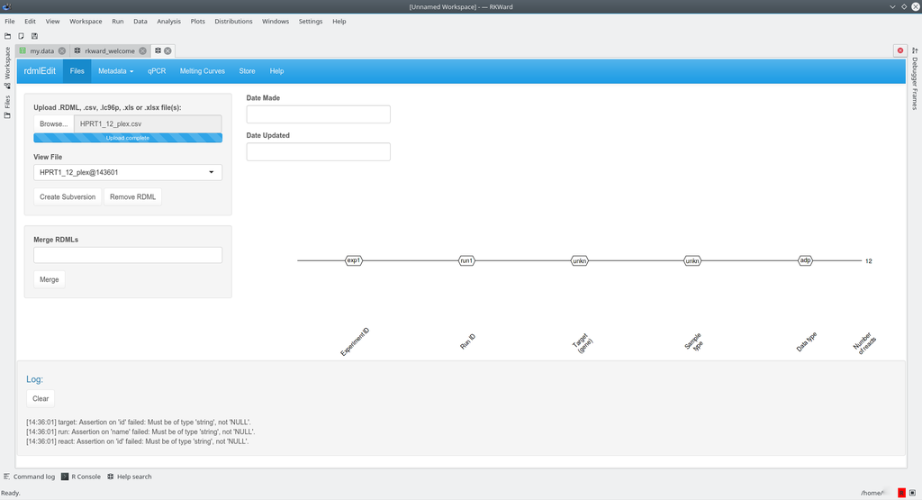

Once imported, this enables `rdmlEDIT()` and other functions from the `RDML` package to conduct complex data visualization and processing in the R statistical computing environment.

[figure not shown]

### 0.1.2 Major functionalities of the RDML package

The public methods of the main R6 “RDML” class can be used to access and process the internally stored RDML data. These methods include:

- **new()** – creates a new RDML object, empty or from a specified RDML file;
- **AsDendrogram()** – plots the structure of an RDML object as a dendrogram;
- **AsTable()** – represents the data contained in an RDML object (except fluorescence data) as a *data.frame*;
- **GetFData()** – gets fluorescence data;
- **SetFData()** – sets fluorescence data to an RDML object;
- **AsXML()** – saves an RDML object as an RDML<sub>v.</sub>1.2 file.

## 0.2 Vendors and software packages supporting RDML

The RDML format is supported by Bio-Rad (CFX 96 and CFX 384), Life Technologies (StepOne, ViiA7, QuantStudio) and Roche (LightCycler~96) thermocycler systems. In addition, several software packages (e.g., **Primer3Plus**, **RDML-Ninja**, **qBase+**) support RDML (Untergasser et al. 2007; Hellemans et al. 2007; J M Ruijter et al. 2009; Pabinger et al. 2014; Jan M Ruijter et al. 2015).

## 0.3 Structure of the **RDML** package

The structure of the **RDML** package mimics the RDML format and provides several [R6](https://CRAN.R-project.org/package=R6/vignettes/Introduction.html) classes that correspond to [RDML v1.2](http://rdml.org/files.php?v=1.2) format types. All major manipulations with RDML data can be performed by a class called **RDML** through its public methods:

- `$new()` – creates new **RDML** object (empty or from specified RDML file)
- `$AsTable()` – represents data contained in **RDML** object (except fluorescent data) as data.frame.
- `$GetFData()` – gets fluorescent data.
- `$SetFData()` – sets fluorescent data to **RDML** object.
- `$AsDendrogram()` – represents structure of **RDML** object as dendrogram.

### 0.3.1 Opening and observing RDML file

In this section, we will use the built-in RDML example file `lc96_bACTXY.rdml`. This file was obtained during the measurement of human DNA concentration by a *LightCycler 96* (Roche) and the *XY-Detect* kit (Syntol, Russia).

To open the `lc96_bACTXY.rdml` file, we have to create a new **RDML** object with its class initializer – `$new()` and the file name as parameter `filename`.

```r
filename <- system.file("extdata/lc96_bACTXY.rdml", package = "RDML")
lc96 <- RDML$new(filename = filename)
```

Next we can check the structure of our new object – `lc96` by printing it.

```r
lc96
```

```
#>  dateMade: 2014-08-19T11:25:48
#>  dateUpdated: 2014-08-27T12:06:21
#>  id: [Roche Diagnostics]
#>  experimenter: []
#>  documentation: []
#>  dye: [FAM, Hex, Texas Red, Cy5]
#>  sample: [Sample 39, Sample 41, Sample 43, Sample 45, Sample 51, Sample 53, Sample 54, Sample 55, Sample 56, Sample 57, Sample 58]
#>  target: [30116ec1-44f6-4c9c-9c69-5d6f00226d4e, 69b0b5cd-591c-4012-a995-7a8b53861548, 7797a698-1b2d-4819-bf7d-1188f2c8ca7f, c16f36ee-8636-40d2-ae72-b00d3b2eb89d, bACT, X, Y, IPC]
#>  thermalCyclingConditions: [2f78ed33-724e-4a29-97e9-92296eb868e1]
#>  experiment: [ca1eb225-ecea-4793-9804-87bfbb45f81d]
```

As a result we can see field names, and after `:`

- names of the `R6` objects contained at this field after `~`,
- contained values after `:`,
- names of list elements enclosed in `[]`.

The field names for all **RDML** package classes correspond to field names of RDML types as described at http://rdml.org/files.php?v=1.2.

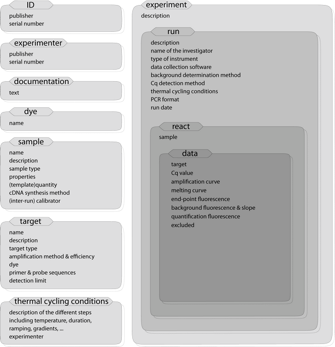

Image source: http://rdml.org/.

For the base class **RDML**, these are:

- `dateMade`
- `dateUpdated`
- `id` – publisher and id to the RDML file.
- `experimenter` – contact details of the experimenter.
- `documentation` – these elements should be used if the same description applies to many samples, targets, or experiments.
- `dye` – information about a dye.
- `sample` – defined template solutions.
- `target` – defined PCR reactions.
- `thermalCyclingConditions` – cycling programs for PCR or to amplify cDNA.
- `experiment`

These fields can be divided by two parts:

#### 0.3.1.1 Experiment field

Contains one or more experiments with fluorescence data. Fluorescence data are stored at the *data* level of an experiment. For example, fluorescence data for reaction tube *45* and target *bACT* can be accessed with the following code:

```r
fdata <-
  lc96$
    experiment$`ca1eb225-ecea-4793-9804-87bfbb45f81d`$
    run$`65aeb1ec-b377-4ef6-b03f-92898d47488b`$
    react$`45`$
    data$bACT$
    adp$fpoints #'adp' means amplification data points (qPCR)
head(fdata)
```

```
#>    cyc     tmp     fluor
#> 1:   1 68.0054 0.0782385
#> 2:   2 68.0429 0.0753689
#> 3:   3 68.0451 0.0736838
#> 4:   4 68.0525 0.0723196
#> 5:   5 68.0537 0.0717019
#> 6:   6 68.0538 0.0714182
```

The structure of experiments can be visualized by plotting dendrograms.

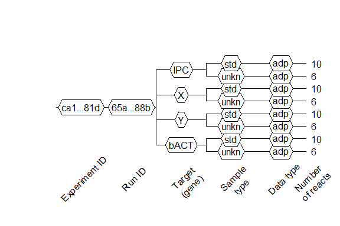

```r
lc96$AsDendrogram()
```

In this dendrogram 1 we can see that our file consists of one experiment and one run. Four targets, each with two sample types (*std* – standard, *unkn* – unknown), are part of the experiment. There is only qPCR data – *adp* in this experiment. Ten reactions (tubes) for standard type (*std*) and six reaction for the unknown (*unkn*) type. The total number of reactions can be more than the number of reactions on the plate because one tube can contain more than one target (e.g., multiplexing).

#### 0.3.1.2 Additional information fields

All fields other than **experiment**. This additional information can be referenced in other parts of the RDML file. For example, to access sample added to react *39* and get its quantity, we can use code like this:

```r
ref <- lc96$
          experiment$`ca1eb225-ecea-4793-9804-87bfbb45f81d`$
          run$`65aeb1ec-b377-4ef6-b03f-92898d47488b`$
          react$`39`$
          sample$id
sample <- lc96$sample[[ref]]
sample$quantity$value
```

### 0.3.2 Copying **RDML** objects

**R6** objects are environments, that’s why simple copying results in creating references to existing objects. Then modifying the copy leads to modification of the original object. To create a *real* copy of the object, we have to use method `$clone(deep = TRUE)` provided by the **R6** class (or its shortcut `$copy()` inside **RDML** package).

```r
id1 <- idType$new("id_1")
id2 <- id1
id3 <- id1$copy()
id2$id <- "id_2"
id3$id <- "id_3"
cat(sprintf("Original object\t\t: %s ('id_1' became 'id_2')\nSimple copy\t\t\t: %s\n'Real' copy (clone)\t: %s\n",
            id1$id, id2$id, id3$id))
```

```
#> Original object      : id_2 ('id_1' became 'id_2')
#> Simple copy          : id_2
#> 'Real' copy (clone)  : id_3
```

From the example above, we can see that the modification of `id2` led to a modification of the original object `id1`, however modification of cloned object `id3` did not.

### 0.3.3 Modifying **RDML** objects

To modify the content of **RDML** objects, we can use fields as setters. These setters provide type safe modifications by input validation. In addition, setting lists of objects generates names of list elements.

```r
## Create 'real' copy of object
experiment <- lc96$experiment$`ca1eb225-ecea-4793-9804-87bfbb45f81d`$copy()
## Try to set 'id' with wrong input type.
## Correct type 'idType' can be seen at error message.
tryCatch(experiment$id <- "exp1",
         error = function(e) print(e))
```

```
#> <simpleError in tools::buildVignettes(dir = ".", tangle = TRUE): Assertion on 'id' failed: Must have class 'idType', but has class 'character'.>
```

```r
## Set 'id' with correct input type - 'idType'
experiment$id <- idType$new("exp1")

## Similar operations for 'run'
run <- experiment$run$`65aeb1ec-b377-4ef6-b03f-92898d47488b`$copy()
run$id <- idType$new("run1")

## Replace original elements with modified
experiment$run <- list(run)
lc96$experiment <- list(experiment)
```

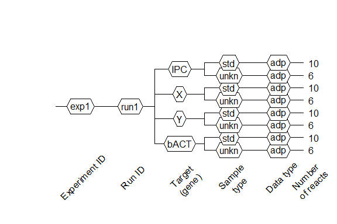

```r
lc96$AsDendrogram()
```

Then, we can observe in 2 our modification with the `$AsDendrogram()` method.

### 0.3.4 `AsTable()` method

To obtain information about all fluorescence data in an RDML file (type of added sample, used target, starting quantity etc.) as a data.frame, we can use the `$AsTable()` method. By default, it provides such information as:

- `fdata.name` – aggregated name for current fluorescence data. Default pattern is `position_sample_sample.type_target` (e.g., *D03_Sample 39_std_bACT*). This pattern can be modified by `name.pattern` argument.
- `exp.id` – experiment id (e.g., *exp1*).
- `run.id` – run id (e.g., *run1*).
- `react.id` – react (tube) id (e.g., *39*).
- `position` – react (tube) position (e.g., *D03*).
- `sample` – name of the added sample (e.g., *Sample 39*).
- `target` – detection target (e.g., *bACT*).
- `target.dyeId` – detection dye (e.g., *FAM*).
- `sample,type` – type of the added sample (e.g., *std*).
- `adp` – `TRUE` if contains qPCR data.
- `mdp` – `TRUE` if contains melting data.

To add custom columns to the output *data.frame*, we should pass it as a named method argument by generating expressions. Values for default columns can be used by custom name patterns and new columns referring to their names. The next example shows how to use the `$AsTable()` method with a custom name pattern and additional columns.

```r
tab <- lc96$AsTable(
  # Custom name pattern 'position~sample~sample.type~target~dye'
  name.pattern = paste(
             react$position,
             react$sample$id,
             private$.sample[[react$sample$id]]$type$value,
             data$tar$id,
             target[[data$tar$id]]$dyeId$id,
             sep = "~"),
  # Custom column 'quantity' - starting quantity of added sample
  quantity = {
    value  <- sample[[react$sample$id]]$quantity$value
    if (is.null(value) || is.na(value)) NULL
    else value
  }
)
## Remove row names for compact printing
rownames(tab) <- NULL
head(tab)
```

```
#>                       fdata.name exp.id run.id react.id position    sample
#> 1:     D03~Sample 39~std~IPC~Cy5   exp1   run1       39      D03 Sample 39
#> 2:       D03~Sample 39~std~X~Hex   exp1   run1       39      D03 Sample 39
#> 3: D03~Sample 39~std~Y~Texas Red   exp1   run1       39      D03 Sample 39
#> 4:    D03~Sample 39~std~bACT~FAM   exp1   run1       39      D03 Sample 39
#> 5:     D04~Sample 39~std~IPC~Cy5   exp1   run1       40      D04 Sample 39
#> 6:       D04~Sample 39~std~X~Hex   exp1   run1       40      D04 Sample 39
#>    target target.dyeId sample.type  adp   mdp
#> 1:    IPC          Cy5         std TRUE FALSE
#> 2:      X          Hex         std TRUE FALSE
#> 3:      Y    Texas Red         std TRUE FALSE
#> 4:   bACT          FAM         std TRUE FALSE
#> 5:    IPC          Cy5         std TRUE FALSE
#> 6:      X          Hex         std TRUE FALSE
```

Here, the generated data.frame is also used as a query in `$GetFData()` and `$SetFData()` methods (see further sections).

### 0.3.5 Getting fluorescence data

We can extract the fluorescence data in two ways:

- direct access to the data as described in the *Experiment field* subsection
- using the special method `$GetFData()`

The advantage of `$GetFData()` is that it can combine fluorescence data from many plates into one data.frame. The major argument of this function is `request`, which defines fluorescence data to be extracted. This request is the output from the `$AsTable()` method and can be easily filtered by the **dplyr** `filter()` function. Furthermore, cycle limits, the output `data.frame` format, as well as data types (`fdata.type = 'adp'` for qPCR, `fdata.type = 'mdp'` for melting data) can by specified (see examples below).

```r
library(dplyr)
```

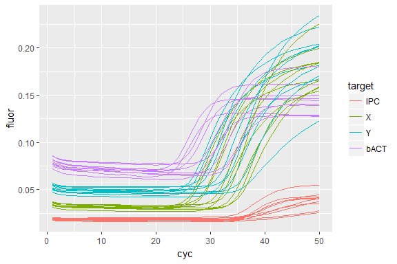

```r
library(ggplot2)

## Prepare request to get only 'std' type samples
filtered.tab <- filter(tab,
                       sample.type == "std")

fdata <- lc96$GetFData(filtered.tab,
                       # long table format for usage with ggplot2
                       long.table = TRUE)
ggplot(fdata, aes(cyc, fluor)) +
    geom_line(aes(group = fdata.name,
                  color = target))
```

Our example curves are not background subtracted, as visible in the plot. To accomplish this, we use the `CPP()` function from the chipPCR package (Rödiger, Burdukiewicz, and Schierack 2015) as described in Rödiger et al. (2015).

```r
library(chipPCR)
tab <- lc96$AsTable(
  # Custom name pattern 'position~sample~sample.type~target~run.id'
  name.pattern = paste(
             react$position,
             react$sample$id,
             private$.sample[[react$sample$id]]$type$value,
             data$tar$id,
             run$id$id, # run id added to names
             sep = "~"))
## Get all fluorescence data
fdata <- as.data.frame(lc96$GetFData(tab,
                                     # We don't need long table format for CPP()
                                     long.table = FALSE))

fdata.cpp <- cbind(cyc = fdata[, 1],
                   apply(fdata[, -1], 2,
                         function(x) CPP(fdata[, 1],
                                         x)$y))
```

Now we have properly preprocessed data, which we will add to our object and use in the next section.

### 0.3.6 Setting fluorescence data

To define fluorescence data as an **RDML** object, we can use the `$SetFData()` method. It takes three arguments:

- `fdata` – fluorescence data in `long.table = FALSE` format
- `request` – output from the `AsTable()` function, which is used to set data;
- `fdata.type` – `fdata.type = 'adp'` for qPCR, `fdata.type = 'mdp'` for melting data.

> Note that the colnames in `fdata` and `fdata.name` in `request` have to be the same!

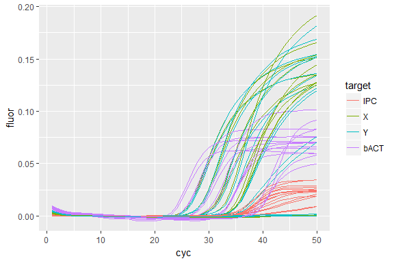

```r
tab$run.id <- "run.cpp"
## Set fluorescence data from previous section
lc96$SetFData(fdata.cpp,
              tab)

## View setted data
fdata <- lc96$GetFData(tab,
                       long.table = TRUE)
ggplot(fdata, aes(cyc, fluor)) +
    geom_line(aes(group = fdata.name,
                  color = target))
```

### 0.3.7 Merging **RDML** objects

Merging **RDML** objects can be conducted by the `MergeRDMLs()` function. It takes a list of **RDML** objects and returns one single **RDML** object.

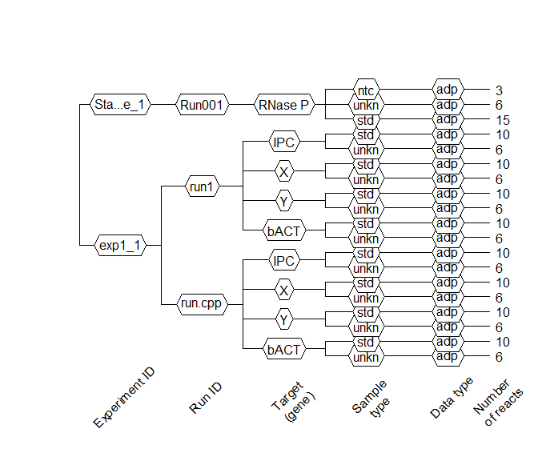

```r
## Load another built in RDML file
stepone <- RDML$new(paste0(path.package("RDML"),
                           "/extdata/", "stepone_std.rdml"))
## Merge it with our 'lc96' object
merged <- MergeRDMLs(list(lc96, stepone))
## View structure of new object
merged$AsDendrogram()
```

### 0.3.8 Saving **RDML** object as RDML file

To save **RDML** objects in RDML file v1.2 format, we can use the `$AsXML()` method where the `file.name` argument is the name of new RDML file. Without `file.name` given, the function returns an XML tree.

`lc96$AsXML("lc96.rdml")`

One can use [RDML-ninja](https://sourceforge.net/projects/qpcr-ninja/) or the [RDML validator](http://rdml.org/tools.php?validator) from the RMDL consortium to validate RDML files created by the **RDML** package.

### 0.3.9 Creating custom functions

**R6** classes allow to add methods to existing classes by using the `$set()` method. Suppose that we want to add a method to preprocess all fluorescence data and calculate Cq values:

```r
RDML$set("public", "CalcCq",
         function() {
           library(chipPCR)
           fdata <- as.data.frame(self$GetFData(
             self$AsTable()))
           fdata <- cbind(cyc = fdata[, 1],
                          apply(fdata[, -1],
                                2,
                                function(x)
                                  # Data preprocessing
                                  CPP(fdata[, 1],
                                      x)$y)
                          )

           apply(fdata[, -1], 2,
                 function(x) {
                   tryCatch(
                     # Calculate Cq
                     th.cyc(fdata[, 1], x,
                            auto = TRUE)@.Data[1],
                     error = function(e) NA)
                 })
         }
)

## Create new object with our advanced class
stepone <- RDML$new(paste0(path.package("RDML"),
                           "/extdata/", "stepone_std.rdml"))
```

We can then apply our new method:

```r
stepone$CalcCq()
```

```
#>         A01_NTC_RNase P_ntc_RNase P         A02_NTC_RNase P_ntc_RNase P
#>                           13.801661                           12.964268
#>         A03_NTC_RNase P_ntc_RNase P       A04_pop1_RNase P_unkn_RNase P
#>                           14.399910                           13.529380
#>       A05_pop1_RNase P_unkn_RNase P       A06_pop1_RNase P_unkn_RNase P
#>                           14.609048                           14.160886
#>       A07_pop2_RNase P_unkn_RNase P       A08_pop2_RNase P_unkn_RNase P
#>                           11.839277                           10.947218
#>       B01_pop2_RNase P_unkn_RNase P B02_STD_RNase P_10000.0_std_RNase P
#>                           13.167509                           13.415532
#> B03_STD_RNase P_10000.0_std_RNase P B04_STD_RNase P_10000.0_std_RNase P
#>                           13.363262                           14.082731
#>  B05_STD_RNase P_5000.0_std_RNase P  B06_STD_RNase P_5000.0_std_RNase P
#>                           13.039183                           14.012804
#>  B07_STD_RNase P_5000.0_std_RNase P  B08_STD_RNase P_2500.0_std_RNase P
#>                            9.790724                           12.981337
#>  C01_STD_RNase P_2500.0_std_RNase P  C02_STD_RNase P_2500.0_std_RNase P
#>                           15.666928                           13.132126
#>  C03_STD_RNase P_1250.0_std_RNase P  C04_STD_RNase P_1250.0_std_RNase P
#>                           13.905808                           14.974769
#>  C05_STD_RNase P_1250.0_std_RNase P   C06_STD_RNase P_625.0_std_RNase P
#>                           13.880906                           12.850727
#>   C07_STD_RNase P_625.0_std_RNase P   C08_STD_RNase P_625.0_std_RNase P
#>                           16.915642                           13.706484
```

### 0.3.10 Creating **RDML** from tables

**RDML** objects can not only be generated from files but also from user data contained in data.frames. For this, we have to create an empty **RDML** object, create a data.frame containing the data and set it by the `$SetFData()` method. Minimal required information (samples, targets, dyes) will be created from the data description.

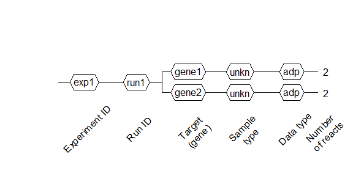

```r
#### Create simulated data with AmpSim() from chipPCR package
## Cq for data to be generated
Cqs <- c(15, 17, 19, 21)
## PCR si,ulation will be 35 cycles
fdata <- data.frame(cyc = 1:35)
for(Cq in Cqs) {
  fdata <- cbind(fdata,
                 AmpSim(cyc = 1:35, Cq = Cq)[, 2])
}
## Set names for fluorescence curves
colnames(fdata)[2:5] <- c("c1", "c2", "c3", "c4")

## Create minimal description
descr <- data.frame(
  fdata.name = c("c1", "c2", "c3", "c4"),
  exp.id = c("exp1", "exp1", "exp1", "exp1"),
  run.id = c("run1", "run1", "run1", "run1"),
  react.id = c(1, 1, 2, 2),
  sample = c("s1", "s1", "s2", "s2"),
  sample.type = c("unkn", "unkn", "unkn", "unkn"),
  target = c("gene1", "gene2", "gene1", "gene2"),
  target.dyeId = c("FAM", "ROX", "FAM", "ROX"),
  stringsAsFactors = FALSE
)

## Create empty RDML object
sim <- RDML$new()
## Add fluorescence data
sim$SetFData(fdata, descr)

## Observe object
sim$AsDendrogram()
```

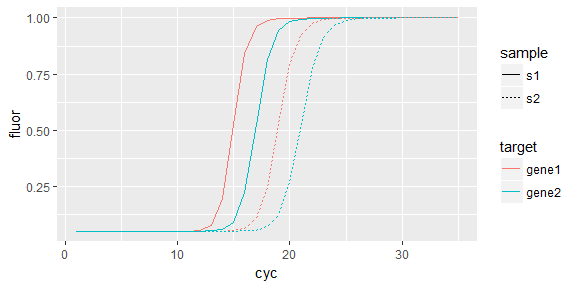

```r
fdata <- sim$GetFData(sim$AsTable(),
                      long.table = TRUE)
ggplot(fdata, aes(cyc, fluor)) +
  geom_line(aes(group = fdata.name,
                color = target,
                linetype = sample))
```

### 0.3.11 Creating **RDML** from *ABI 7500 v.2* software

**RDML** objects can be created from *.eds* files generated by the *ABI 7500 v.2* or *StepOne* software (here, all analyses have to be conducted within the device software!).

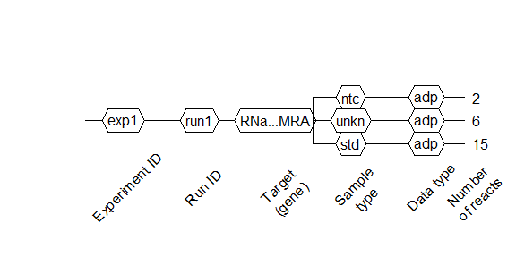

```r
filename <- system.file("extdata/from_abi7500/sce.eds", package = "RDML")
abi <- RDML$new(filename = filename)
abi$AsDendrogram()
```

### 0.3.12 Creating **RDML** from *.csv* files

**RDML** objects can be generated from *.csv* files. The files need to contain a first column named **cyc** for qPCR data or **tmp** for melting data. The remaining columns must contain the raw fluorescence signals.

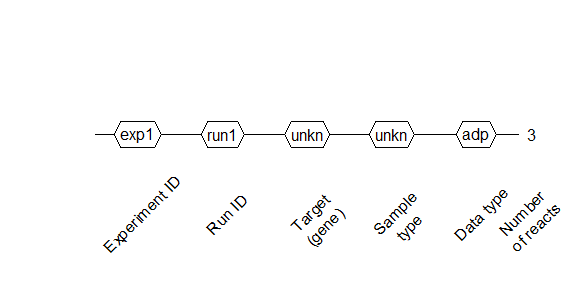

```r
filename <- system.file("extdata/from_tables/fdata.csv", package = "RDML")
csv <- RDML$new(filename = filename)
csv$AsDendrogram()
```

### 0.3.13 Creating **RDML** from *.xls* or *.xslx* files

**RDML** objects can also be generated from *.xls* or *.xslx* files. The files need to contain a *description* data.frame at tab sheet *description* and qPCR data at tab sheet *adp*, and/or qPCR data at tab sheet *mdp*.

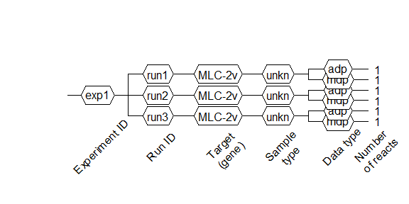

```r
filename <- system.file("extdata/from_tables/table.xlsx", package = "RDML")
xslx <- RDML$new(filename = filename)
xslx$AsDendrogram()
```

### 0.3.14 Functional style

To provide a functional programming style that is more convenient in **R**, the **RDML** class methods have function wrappers:

- `obj$AsTable(...)` – `AsTable(obj, ...)`
- `obj$SetFData(...)` – `SetFData(obj, ...)`
- `obj$GetFData(...)` – `GetFData(obj, ...)`
- `obj$AsDendrogram(...)` – `AsDendrogram(obj, ...)`

### 0.3.16 Summary

The **RDML** package provides classes and methods to work with RDML data generated by real-time quantitative PCR devices or enables creating RDML files from user generated data. Because classes of the **RDML** package are built with **R6**, they can be modified by adding custom methods and ensure type safe usage through input validation.

[output not shown]

# 1 Creating RDML file from raw data

This vignette describes important step how to create **RDML** object from user provided data and calculate Cq values with custom **RDML** class method. We use a real-world example to demonstrate the use of the **RDML** package.

For this purpose we used data from the *VideoScan* platform. The *VideoScan* platform is a highly versatile fluorescence microscope based imaging platform for the real-time analysis of biomolecular interactions. *VideoScan* has been extended by a heating/cooling-unit, which can be used for DNA melting curve analysis (Rödiger, Böhm, and Schimke 2013), real-time quantitative PCR (Rödiger et al. 2013) and quantitative isothermal amplification (Spiess et al. 2015). In this example we focus on qPCR data obtained from the amplification of the human gene *mlc-2v* (Sheikh, Lyon, and Chen 2015). The experimental details (e.g., primer sequences, amplification conditions) are described in (Rödiger et al. 2013; George et al. 2016).

In detail, this dataset contains three amplification curves collected by three runs monitored with TaqMan qPCR chemistry. Similar to other experimental platforms has the *VideoScan* systems an output as *csv* file (comma separated value). In general, *csv* is a format that is sufficient for an in house usage. However, the exchange with other scientists is demanding, since experimental metadata is not consistently included in csv files. These are for example information about qPCR conditions, primers, experimentalist and so on as described in the MIQE and RDML standard documentations.

All *csv* raw data were transferred to the **R** environment and stored as *rda* files in the **C54** dataset after completion of the experiment as described elsewhere (R Development Core Team 2012). The **R** environment provides numerous packages for the import of standard file formats, including formats from spread sheet applications (e.g., *XLS*, *XLSX*, *ODS*) (Schutten 2014, Warnes et al. (2015), Dragulescu (2014)), an ODBC connection (Ripley and 2002) 2015) or from the clipboard (`read.table("clipboard")`). There are several graphical user interfaces (GUIs) for **R**, which facilitate an easy import of raw data (Valero-Mora and Ledesma 2012). For example **RKWard** (Rödiger et al. 2012) has import functionality for *csv*, *txt*, *spss* and *stata* files.

We will use the **C54** dataset directly from the chipPCR package (Rödiger, Burdukiewicz, and Schierack 2015). The amplification curves have different number of cycles and one of them contains a missing value due to a sensor dropout. Thus, this data should be preprocessed before Cq calculation.

**R** is a language with dynamic typing. This is helpful while scripting, but can lead to problematic debugging of more complicated workflows. *R6* classes provide type-safe interfaces to set data without access to the inner structure of objects so that all imported data can be validated. This option is highly useful when creating packages at an intermediate level for other packages (e.g., such an approach does not permit set type *character* in place of type *integer*). Furthermore, the inheritance of *R6* objects unifies the structure of the package and streamlines the extending of its capabilities (since the whole package is written around a single base class).

## 1.1 Initialization

First of all we have to load all necessary packages and fluorescence data into our **R** session.

```r
library(RDML)
library(chipPCR)
library(MBmca)
library(ggplot2)
data(C54)
```

We can see that our data are arranged in data.frame with cycle numbers in the first column and fluorescence values in the other columns. Such data structure is ready to use with the **RDML** package and does not need any conversion.

```r
str(C54)
```

```
#> 'data.frame':    56 obs. of  4 variables:
#>  $ Cycle: num  0 1 2 3 4 5 6 7 8 9 ...
#>  $ D1   : num  0.141 0.146 0.152 0.151 0.153 ...
#>  $ D2   : num  0.148 0.148 0.148 0.149 0.149 ...
#>  $ D3   : num  0.145 0.147 0.148 0.148 0.149 ...
```

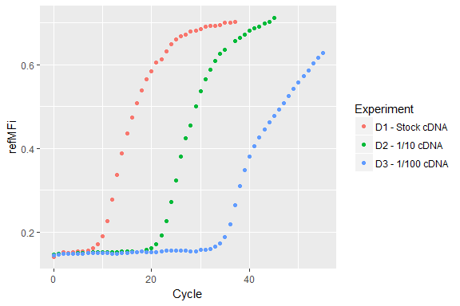

```r
dat <- data.frame(Cycle = rep(C54[, 1], ncol(C54) - 1),
                  Experiment = unlist(lapply(colnames(C54)[-1], function(i) rep(i, nrow(C54)))),
                  refMFi = unlist(C54[, -1]))
levels(dat[["Experiment"]]) <- c("D1 - Stock cDNA", "D2 - 1/10 cDNA", "D3 - 1/100 cDNA")

ggplot(dat, aes(x = Cycle, y = refMFi, colour = Experiment)) + geom_point()
```

## 1.2 Creating custom method for **RDML** class

The preprocessing and Cq calculation steps are held within a **RDML** object. To do this we shall add custom method to the **RDML** class and use this advanced class as **RDML** object initializator (data import).

As described previously (Rödiger et al. 2015), we first preprocess the raw data with the **CPP** function from the chipPCR package. Next, these preprocessed data are stored in new runs within the same experiment. For Cq calculation we used the **diffQ2** function from the MBmca (Rödiger, Böhm, and Schimke 2013) package. Note, there are other functions available within **R** to determine the Cq values. The qpcR package is one of the most popular packages for such tasks.

Additional our method will have two arguments:

- vector `last.cycle` – cycle limits for every amplification curve;
- list `bg.range` – background range for every amplification curve.

```r
RDML$set("public", "ProcessVideoScan",
         function(last.cycle,
                  bg.range) {
           # Get curves description
           tab <- as.data.frame(self$AsTable())
           # Get fluorescent point
           dat <- as.data.frame(self$GetFData(tab))
           # Give new names to runs
           # Preprocess amplification curve raw data as described in
           # R&ouml;diger et al. (2015) Bioinformatics. Note that the dataset
           # has different length of cycle numbers and missing values (NAs).
           # The CPP function from the chipPCR package prepares the data for
           # further analysis.
           tab[, "run.id"] <- paste0(tab[, "run.id"], "_CPP")

           # Curves will be used one by one
           for(i in 2:length(dat)) {
             # Preprocess data
             preprocessed <- CPP(dat[1:last.cycle[i - 1], 1],
                                 dat[1:last.cycle[i - 1], i],
                                 trans = TRUE,
                                 bg.range = bg.range[[i - 1]])[["y.norm"]]
             # Create data.frame with cycle number and preprocessed curve Then
             # give name to fluorescence points columns as before preprocessing
             dat_CPP <- cbind(dat[1:last.cycle[i - 1], 1],
                              preprocessed)
             colnames(dat_CPP)[2] <- tab$fdata.name[i - 1]
             # Set preprocessed data with new description (new run names)
             self$SetFData(dat_CPP, tab)
             # Calculate and set Cq
             # Set Cq from second derivative maximum method as described in
             # R&ouml;diger et al. (2015) Bioinformatics for preprocessed data.
             # The diffQ2 function from the MBmca package
             # (R&ouml;diger et al. (2013), The R Journal) was used to calculate the
             # Cq values of each amplification curve.
             cq <- diffQ2(dat_CPP, inder = TRUE)[["xTm1.2.D2"]][1]
             self$experiment[[tab[i - 1, "exp.id"]]]$
               run[[tab[i - 1, "run.id"]]]$
               react[[tab[i - 1, "react.id"]]]$
               data[[tab[i - 1, "target"]]]$cq <- cq
           }
         }, overwrite = TRUE
)
```

## 1.3 **RDML** object creation

Now we can create an empty **RDML** object with our advanced class and set the fluorescence data into it. For setting the data we have to create a description (metadata) of the amplification curves, which contain:

- `fdata.name` – curve name. Have to be as columns names in data.frame with fluorescence data.
- `exp.id` – experiment name.
- `run.id` – run name. In our case we have three runs.
- `react.id` – react ID. E.g., number of tube within a reaction plate.
- `sample` – sample name.
- `type` – sample type.
- `target` – target name. E.g., gene of interest name.
- `target.dyeID` – fluorescent dye used for detection.

```r
# Create a data frame of metadata
description <- data.frame(
  fdata.name = c("D1", "D2", "D3"),
  exp.id = c("exp1", "exp1", "exp1"),
  run.id = c("run1", "run2", "run3"),
  react.id = c(1, 1, 1),
  sample = c("D1 - Stock cDNA", "D2 - 1/10 cDNA", "D3 - 1/100 cDNA"),
  sample.type = c("unkn", "unkn", "unkn"),
  target = c("MLC-2v", "MLC-2v", "MLC-2v"),
  target.dyeId = c("Cy5", "Cy5", "Cy5"),
  stringsAsFactors = FALSE
)

# Create an empty RDML object
video.scan <- RDML$new()

# Add fluorescence data and metadata to the RDML object from a given source.
# For the sake of simplicity we use the C54 dataset from the chipPCR package.
video.scan$SetFData(C54, description)
```

## 1.4 Setting additional information

As optional step, we can add some information about our experiment. Such as experimenter contacts, references to documentation, description of samples and targets, thermal cycling conditions, etc.

```r
# Add experimentalist information
video.scan$experimenter <-
  list(
    experimenterType$new(
      idType$new("SR"),
      "Stefan",
      "Roediger",
      "stefan.roediger@b-tu.de"
    ),
    experimenterType$new(
      idType$new("CD"),
      "Claudia",
      "Deutschmann"
    )
  )

# Add a reference to documentation
video.scan$documentation <- list(
  documentationType$new(
    idType$new("Roediger et al. 2013"),
    paste("A Highly Versatile Microscope Imaging Technology Platform for the Multiplex",
          "Real-Time Detection of Biomolecules and Autoimmune Antibodies. S. Roediger,",
          "P. Schierack, A. Boehm, J. Nitschke, I. Berger, U. Froemmel, C. Schmidt, M.",
          "Ruhland, I. Schimke, D. Roggenbuck, W. Lehmann and C. Schroeder. Advances in",
          "Biochemical Bioengineering/Biotechnology. 133:33-74, 2013.",
          "https://www.ncbi.nlm.nih.gov/pubmed/22437246")
  )
)

cdna <-
  cdnaSynthesisMethodType$new(
    enzyme = "SuperScript II",
    primingMethod =
      primingMethodType$new("oligo-dt"),
    dnaseTreatment = TRUE
  )
video.scan$sample$`D1 - Stock cDNA`$description <- "Input stock cDNA was used undiluted (D1)"
video.scan$sample$`D1 - Stock cDNA`$cdnaSynthesisMethod <- cdna
video.scan$sample$`D2 - 1/10 cDNA`$description <- "1/1000 diluted in A. bidest"
video.scan$sample$`D2 - 1/10 cDNA`$cdnaSynthesisMethod <- cdna
video.scan$sample$`D3 - 1/100 cDNA`$description <- "1/1000000 diluted in A. bidest"
video.scan$sample$`D3 - 1/100 cDNA`$cdnaSynthesisMethod <- cdna

video.scan$target$`MLC-2v`$xRef <- list(
  xRefType$new("uniprot",
               "P10916")
)
video.scan$target$`MLC-2v`$sequences <-
  sequencesType$new(
    forwardPrimer <- oligoType$new(
      sequence = "ACAGGGATGGCTTCATTGAC"),
    reversePrimer <- oligoType$new(
      sequence = "ATGCGTTGAGAATGGTTTCC"),
    probe1 <- oligoType$new(
      threePrimeTag = "Atto647N",
      sequence = "CAGGGTCCGCTCCCTTAAGTTTCTCC",
      fivePrimeTag = "BHQ2")
  )

tcc <-
  thermalCyclingConditionsType$new(
    idType$new("Amplification"),
    experimenter = list(
      idReferencesType$new("SR"),
      idReferencesType$new("CD")
    ),
    step =
      list(
        stepType$new(
          nr = 1,
          temperature = temperatureType$new(95,
                                            600)
        ),
        stepType$new(
          nr = 2,
          temperature = temperatureType$new(95,
                                            40)
        ),
        stepType$new(
          nr = 3,
          temperature = temperatureType$new(58.5,
                                            90)
        ),
        stepType$new(
          nr = 4,
          temperature = temperatureType$new(68.5,
                                            90)
        ),
        stepType$new(
          nr = 5,
          loop = loopType$new(goto = 2,
                              repeat.n = 49)
        )
      )
  )
video.scan$thermalCyclingConditions <- list(
  tcc
)

#add description of the experiment
video.scan$experiment$exp1$description <-
  paste("The aim was to amplify MLC-2v in the VideoScan and to monitor with a",
        "hydrolysis probe for MLC-2v. The primer sequences for MLC-2v were taken",
        "from Roediger et al. (2013). The amplification was detected in solution of",
        "the 1 HCU (see Roediger et al. 2013 for details). A 20 micro L PCR reaction",
        "was composed of 250 nM primer (forward and reverse), 1x Maxima Probe qPCR",
        "Master Mix (Fermentas), 1 micro L template (MLC-2v amplification product in",
        "different dilutions), 50 nM hydrolysis probe for MLC-2v and A.",
        "bidest. During the amplification, fluorescence was measured at 59.5 degree",
        "Celsius. The Cy5 channel was used to monitor the MLC-2v specific hydrolysis",
        "probe. Input stock cDNA was used undiluted (D1). D2 was 1/1000 and D3",
        "1/1000000 diluted in A. bidest. The D1, D2, and D3 have different numbers",
        "measure points and D2 contains a missing value at cycle 37.")
video.scan$experiment$exp1$run$run1$thermalCyclingConditions <- idReferencesType$new("Amplification")
video.scan$experiment$exp1$run$run2$thermalCyclingConditions <- idReferencesType$new("Amplification")
video.scan$experiment$exp1$run$run3$thermalCyclingConditions <- idReferencesType$new("Amplification")
```

## 1.5 Processing data

After creating **RDML** object and setting data we can use our method `$ProcessVideoScan`.

```r
# Process VideoScan data
video.scan$ProcessVideoScan(last.cycle = c(35, 45, 55),
                            bg.range = list(c(1,8),
                                            NULL,
                                            NULL))
```

Then visualize the object with the `$AsDendrogram` method (runs with IDs that include `_CPP` in names, contain the preprocessed curves):

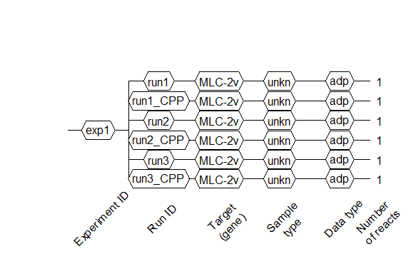

```r
# Visualize RDML object
video.scan$AsDendrogram()
```

And plot preprocessed curves indicating the Cq values:

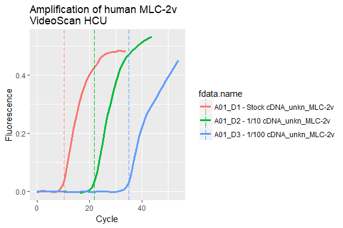

```r
## Visualise preprocessed data with Cq values as vertical dashed lines
# Add custom column that contains the calculated Cq
tab <- video.scan$AsTable(
  cq = {
    cq <- data$cq
    if (is.null(cq) || is.na(cq))
      NULL
    else
      cq
  })
# Get preprocessed data in 'long.table' format
dat <- video.scan$GetFData(tab[grepl("_CPP", tab[["run.id"]]), ],
                           long.table = TRUE)
ggplot(dat, aes(x = cyc, y = fluor)) +
  geom_line(aes(group = fdata.name, color = fdata.name),
            size = 1.2) +
  geom_vline(aes(xintercept = cq, color = fdata.name),
             linetype = "longdash") +
  scale_x_continuous("Cycle") +
  scale_y_continuous("Fluorescence") +
  ggtitle("Amplification of human MLC-2v\nVideoScan HCU")
```

However, there are further **R** packages on [CRAN](https://cran.r-project.org/), [Bioconductor](http://bioconductor.org/) and [GitHub](https://github.com/), which can be used with the RDML package (Rödiger et al. 2015) to deal with non-detects (McCall et al. 2014), normalization (Perkins et al. 2012), expression analysis (Dvinge and Bertone 2009, matz_no_2013) and periodicity in qPCR systems (Spiess et al. 2016).

## 1.6 Export to file

To save our **RDML** object as file we can use `$AsXML()` method with file name as argument:

`video.scan$AsXML("filename.RDML")`

*Note that currently due to limits of `XML` package it is rather slow operation!!!*

A XML files can be compressed to save space. The **RMDL** package uses the `zip()` function from the **utils** package with default values to compress the RDML file. Therefore, the compression mode depends on the operating system. The **RDML** function `AsXML()` without an argument returns one string, which contains the XML data. This can be used to compress it with any other compression algorithm.

## 1.7 Benchmark of the RDML generation

The XML format becomes less efficient to work with at larger file sizes and complex structured information (e.g., matrices). Therefore, a limitation of RMDL is the process of the file generation. This characteristic is inherited by the **RDML** package. Speed is an issue in high-throughput applications. To give the user a foundation for a decision support if the implementation of the RMDL format is advisable, we performed a benchmark. We used the **microbenchmark** package (Olaf Mersmann and Friedman 2014, Radford (2014)) to assess the time required for generation of RDML files. The simulation included datasets with ranging from 1 to 1000 entries per file.

## 1.8 Dealing with other data formats

Researchers often collect gene expression data from more than one laboratory and and are thus required to analyze and aggregate many data sets. Adaptable data management - also known as “adaptive informatics” - is relevant in cases where data from different omics approaches and assays (e.g., flow cytometry, digital PCR, NGS) need to be merged (Baker 2012). As RDML is based on XML, it is possible to converge the files with other formats such as HDF, (Millard et al. 2011) which is supported by **R** (Fischer and Pau 2015). This enables extended data storage and analysis, but also a higher level of experimental data management.

## 1.9 Conclusion

In this example we used raw data from the *VideoScan* platform to demonstrate the creation of an *RDML* file via the **RDML** package. This procedure can be easily adapted to other experiments and devices and gives the researcher a tool to create a file in a standardized format for convenient data exchange. In contrast to simple *csv* files contains this file additional metadata in a defined structure. This in turn makes the data available to other scientists for reproducible research.

## 1.10 Benchmark

The RDML format may also store data from high-throughput technologies such as digital PCR or 384-well qPCR. To make the RDML package the most appropriate tool for these applications, we optimized the saving functionality of the package. Hence, the RDML package is able to save even large numbers of qPCR experiments in reasonable time.

We benchmarked the time needed for saving RDML object with different numbers of experiments on two desktop machines:

1. Windows 7 x64 (build 7601) Service Pack 1 on Intel Core i5 (2,40 GHz) with 4,00 GB RAM. R version 3.2.1 (2015-06-18).
2. Kubuntu 15.04 (Kernel 3.19.0-27-generic) Intel(R) Pentium(R) CPU 997 @ 1.60GHz with 4,00 GB RAM. R version 3.1.2 (2014-10-31).

To warrant fairest comparison and taking into account factors like garbage collection, we repeated the procedure 100 times.

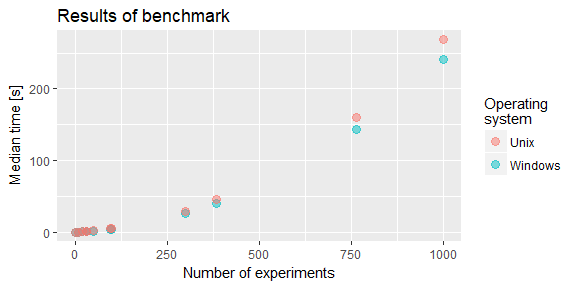

Results of benchmark.

| Number of experiments | Median time [s] | Operating System |
| --- | --- | --- |
| 1 | 0.0525600 | Windows |
| 8 | 0.1965201 | Windows |
| 20 | 0.4882732 | Windows |
| 30 | 0.7770339 | Windows |
| 32 | 0.8454795 | Windows |
| 50 | 1.4801968 | Windows |
| 96 | 3.8208417 | Windows |
| 100 | 4.0498602 | Windows |
| 300 | 25.6566066 | Windows |
| 384 | 39.9697519 | Windows |
| 765 | 142.1440033 | Windows |
| 1000 | 239.7105810 | Windows |
| 1 | 0.0665418 | Unix |
| 8 | 0.2468777 | Unix |
| 20 | 0.6101219 | Unix |
| 30 | 0.9658560 | Unix |
| 32 | 1.0468907 | Unix |
| 50 | 1.8240828 | Unix |
| 96 | 4.5716005 | Unix |
| 100 | 4.8454858 | Unix |
| 300 | 29.0860889 | Unix |
| 384 | 44.9543657 | Unix |
| 765 | 159.6792129 | Unix |
| 1000 | 266.5159046 | Unix |

The results above indicate that, thanks to the RDML package, an average laboratory workstation is able to save large RDML files in reasonable time (around 4 minutes for 1000 experiments).

## 1.11 Validation of RDML files created by the RDML package

The correct structure of an RDML file is an important prerequisite to perform reproducible analysis. Unfortunately, the created files can not be properly tested to date because the official RDML validator [rdml.org](http://rdml.org/tools.php) is not online from time to time. However, there is a solution to validate the files by the alternate editor - *RDML-Ninja* (Jan M Ruijter et al. 2015).

## 1.12 RDMLedit web-server

The http://shtest.evrogen.net/rdmlEdit/ is a web tool based on the functionalities of the RDML package. Aside from basic functionalities like data import, modification and export, RDMLedit also produces visualisations of qPCR data. In addition, RDMLedit can also merge multiple RDML files.

### 1.12.1 Local deployment of RDMLedit

As a https://shiny.rstudio.com/, RDMLedit may be also deployed locally. It requires an installed R and RDML package. To initialize, the user has to open R and run the following command: **rdmlEdit()**.

## References

Baker, Monya. 2012. “Quantitative Data: Learning to Share.” *Nature Methods* 9 (1): 39–41. www.nature.com/nmeth/journal/v9/n1/abs/nmeth.1815.html.

Chang, Winston. 2015. *R6: Classes with Reference Semantics*. https://CRAN.R-project.org/package=R6.

Dragulescu, Adrian A. 2014. *Xlsx: Read, Write, Format Excel 2007 and Excel 97/2000/XP/2003 Files*. https://CRAN.R-project.org/package=xlsx.

Dvinge, Heidi, and Paul Bertone. 2009. “HTqPCR: High-Throughput Analysis and Visualization of Quantitative Real-Time PCR Data in R.” *Bioinformatics* 25 (24): 3325–6. doi:10.1093/bioinformatics/btp578.

Fischer, Bernd, and Gregoire Pau. 2015. “rhdf5: HDF5 Interface to R.” *R Package Version 2.10.0*. https://www.bioconductor.org/packages/release/bioc/html/rhdf5.html.

George, Sandra, Stefan Rödiger, Christian Schröder, Michael Knaut, and Jan-Heiner Küpper. 2016. “Development of Multiplex PCR Systems for Expression Profiling of Human Cardiomyocytes Induced to Proliferate by Lentivirus Transduction of Upcyte Genes.” *Journal of Cellular Biotechnology* 2 (1): 35–55. doi:10.3233/JCB-15025.

Hellemans, Jan, Geert Mortier, Anne De Paepe, Frank Speleman, and Jo Vandesompele. 2007. “qBase Relative Quantification Framework and Software for Management and Automated Analysis of Real-Time Quantitative PCR Data.” *Genome Biology* 8 (2): R19. doi:10.1186/gb-2007-8-2-r19.

Lang, Duncan Temple, and the CRAN Team. 2015. *XML: Tools for Parsing and Generating XML Within R and S-Plus*. https://CRAN.R-project.org/package=XML.

Lefever, Steve, Jan Hellemans, Filip Pattyn, Daniel R. Przybylski, Chris Taylor, René Geurts, Andreas Untergasser, and Jo Vandesompele. 2009. “RDML: Structured Language and Reporting Guidelines for Real-Time Quantitative PCR Data.” *Nucleic Acids Research* 37 (7): 2065–9. https://nar.oxfordjournals.org/content/37/7/2065.

McCall, Matthew N., Helene R. McMurray, Hartmut Land, and Anthony Almudevar. 2014. “On Non-Detects in qPCR Data.” *Bioinformatics* 30 (16): 2310–6. doi:10.1093/bioinformatics/btu239.

Millard, Bjorn L., Mario Niepel, Michael P. Menden, Jeremy L. Muhlich, and Peter K. Sorger. 2011. “Adaptive Informatics for Multifactorial and High-Content Biological Data.” *Nature Methods* 8 (6): 487–92.

Nolan, Deborah, and Duncan Temple Lang. 2014. *XML and Web Technologies for Data Sciences with R*. Springer. https://www.springer.com/statistics/computational+statistics/book/978-1-4614-7899-7.

Olaf Mersmann, Rainer Hurling, Claudia Beleites, and Ari Friedman. 2014. *microbenchmark: Accurate Timing Functions*. https://CRAN.R-project.org/package=microbenchmark.

Pabinger, Stephan, Stefan Rödiger, Albert Kriegner, Klemens Vierlinger, and Andreas Weinhäusel. 2014. “A Survey of Tools for the Analysis of Quantitative PCR (qPCR) Data.” *Biomolecular Detection and Quantification* 1 (1): 23–33.

Perkins, James R., John M. Dawes, Steve B. McMahon, David LH Bennett, Christine Orengo, and Matthias Kohl. 2012. “ReadqPCR and NormqPCR: R Packages for the Reading, Quality Checking and Normalisation of RT-qPCR Quantification Cycle (Cq) Data.” *BMC Genomics* 13 (1): 296. doi:10.1186/1471-2164-13-296.

R Development Core Team. 2012. *R Data Import/Export*. Vienna, Austria: R Foundation for Statistical Computing. https://www.R-project.org/.

Radford, Neal. 2014. *Inaccurate Results from Microbenchmark*. https://web.archive.org/web/20140823221902/https://www.r-bloggers.com/inaccurate-results-from-microbenchmark/.

Ren, Kun. 2015. *rlist: A Toolbox for Non-Tabular Data Manipulation*. https://CRAN.R-project.org/package=rlist.

Ripley, Brian, and Michael Lapsley (1999 to Oct 2002). 2015. *RODBC: ODBC Database Access*. https://CRAN.R-project.org/package=RODBC.

Rödiger, Stefan, Alexander Böhm, and Ingolf Schimke. 2013. “Surface Melting Curve Analysis with R.” *The R Journal* 5 (2): 37–53. https://journal.r-project.org/archive/2013-2/roediger-bohm-schimke.pdf.

Rödiger, Stefan, Michał Burdukiewicz, and Peter Schierack. 2015. “chipPCR: an R package to pre-process raw data of amplification curves.” *Bioinformatics* 31 (17): 2900–2902. https://bioinformatics.oxfordjournals.org/content/31/17/2900.abstract.

Rödiger, Stefan, Michał Burdukiewicz, Konstantin Blagodatskikh, and Peter Schierack. 2015. “R as an Environment for the Reproducible Analysis of Dna Amplification Experiments.” *The R Journal* 7 (2): 127–50.

Rödiger, Stefan, Thomas Friedrichsmeier, Prasenjit Kapat, and Meik Michalke. 2012. “RKWard: A Comprehensive Graphical User Interface and Integrated Development Environment for Statistical Analysis with R.” *Journal of Statistical Software* 49 (9): 1–34. https://www.jstatsoft.org/article/view/v049i09.

Rödiger, Stefan, Peter Schierack, Alexander Böhm, Jörg Nitschke, Ingo Berger, Ulrike Frömmel, Carsten Schmidt, et al. 2013. “A highly versatile microscope imaging technology platform for the multiplex real-time detection of biomolecules and autoimmune antibodies.” *Advances in Biochemical Engineering/Biotechnology* 133: 35–74.

Ruijter, J M, C Ramakers, W M H Hoogaars, Y Karlen, O Bakker, M J B van den Hoff, and A F M Moorman. 2009. “Amplification Efficiency: Linking Baseline and Bias in the Analysis of Quantitative PCR Data.” *Nucleic Acids Research* 37 (6): e45.

Ruijter, Jan M, Steve Lefever, Jasper Anckaert, Jan Hellemans, Michael W Pfaffl, Vladimir Benes, Stephen A Bustin, Jo Vandesompele, Andreas Untergasser, and others. 2015. “RDML-Ninja and RDMLdb for Standardized Exchange of qPCR Data.” *BMC Bioinformatics* 16 (1). BioMed Central Ltd: 197.

Schutten, Gerrit-Jan. 2014. *readODS: Read ODS Files and Puts Them into Data Frames*. https://CRAN.R-project.org/package=readODS.

Sheikh, Farah, Robert C. Lyon, and Ju Chen. 2015. “Functions of Myosin Light Chain-2 (MYL2) in Cardiac Muscle and Disease.” *Gene* 569 (1): 14–20.

Spiess, Andrej-Nikolai, Claudia Deutschmann, Michał Burdukiewicz, Ralf Himmelreich, Katharina Klat, Peter Schierack, and Stefan Rödiger. 2015. “Impact of Smoothing on Parameter Estimation in Quantitative DNA Amplification Experiments.” *Clinical Chemistry* 61 (2): 379–88. doi:10.1373/clinchem.2014.230656.

Spiess, Andrej-Nikolai, Stefan Rödiger, Michał Burdukiewicz, Thomas Volksdorf, and Joel Tellinghuisen. 2016. “System-Specific Periodicity in Quantitative Real-Time Polymerase Chain Reaction Data Questions Threshold-Based Quantitation.” *Scientific Reports* 6 (December): 38951. doi:10.1038/srep38951.

Untergasser, Andreas, Harm Nijveen, Xiangyu Rao, Ton Bisseling, René Geurts, and Jack A. M. Leunissen. 2007. “Primer3Plus, an Enhanced Web Interface to Primer3.” *Nucleic Acids Research* 35 (suppl 2): W71–W74. doi:10.1093/nar/gkm306.

Valero-Mora, Pedro M., and Ruben Ledesma. 2012. “Graphical User Interfaces for R.” *Journal of Statistical Software* 49 (1): 1–8. https://www.jstatsoft.org/article/view/v049i01.

Warnes, Gregory R., Ben Bolker, Gregor Gorjanc, Gabor Grothendieck, Ales Korosec, Thomas Lumley, Don MacQueen, Arni Magnusson, Jim Rogers, and others. 2015. *gdata: Various R Programming Tools for Data Manipulation*. https://CRAN.R-project.org/package=gdata.

Wickham, Hadley. 2011. “The Split-Apply-Combine Strategy for Data Analysis.” *Journal of Statistical Software* 40 (1): 1–29. https://www.jstatsoft.org/article/view/v040i01.

———. 2013. *assertthat: Easy Pre and Post Assertions.* https://CRAN.R-project.org/package=assertthat.

———. 2014. *tidyr: Easily Tidy Data with Spread() and Gather() Functions.* https://CRAN.R-project.org/package=tidyr.

Wickham, Hadley, and Romain Francois. 2015. *dplyr: A Grammar of Data Manipulation*. https://CRAN.R-project.org/package=dplyr.